# Tag 2

Nochmal Wiederholung Hackpad (kollaborativer Editor)

Siehe: https://hackmd.io/mDRVzB8GTQ-CicaCJYhe5A?both

## Python (Fortsetzung)

Erklärung von Python Kernsprache - Standard Bibliotheken - Third Party Libraries Wir werden uns mit Penders beschäftigen. Hier: Data frame, womit man gut Tabellen, tabulatorisch arbeiten kann (theoretisch beliebig große Datenmengen und Spalten/Zeilen-Anzahlen)

Pandas ist mitverantwortlich für die hohe Präsenz von Python in der Daten-Community und stammt ursprünglich aus R

Betrachte nun OpenAPC (Teaser für später) als Beispiel für GitHub: Kollaborative Datensammlung, in diesem Fall für Open Access Processing Charges (wer hat wieviel gezahlt für was). Wir lernen gleich, hier die Daten rauszuziehen und uns die Informationen, die wir haben wollen (anhand von einem Beispiel) mit pandas da heraus ziehen.

## Intro to Pandas

Hier nun erstmal Bibliotheken importieren

```python
import pandas as pd #pd ist hier eine Konvention
import urllib.request
```

```python
#Modul importieren (Submodul mit .). Nicht verwechseln mit Variable.methode! (Punkt bedeutet was anderes)
url = "https://raw.githubusercontent.com/OpenAPC/openapc-de/master/data/fuberlin/APC_FU_Berlin_2015.csv"
```

Die URL hier stammt aus unserem HackPad (unten unter "Codesnippets")

```python
apc_file = "openapc.csv"#comma/character seperated values = Csv
```

Auf manchen Windows-Systemen funktioniert es nicht, aber man kann durch ! hier auch Bash-Befehle einfügen und ausführen

```python
urllib.request.urlretrieve(url, apc_file)
#die Fkt urlretrieve braucht zwei Argumente: Quelle und Ziel. Quelle ist unsere URL, Ziel ist die csv-Datei
```

```
('openapc.csv', <http.client.HTTPMessage at 0x26b9d11c5c0>)
```

Beachte: Die meisten Funktionen geben uns etwas zurück (return). Diese gibt uns Bissl Information zurück. Was hier wichtig ist, ist, dass diese Datei jetzt auf dem PC gespeichert ist (im Verzeichnis, in dem ich mich gerade befinde)

```python
for line in open(apc_file): #open(x) ist eine built-in function von Python. Open sucht im Verzeichnis nach der Datei x
    #das Ding in der For-Schleife VERHÄLT sich wie eine Liste, daher kann die Schleife gewohnt agieren
    print(line.strip())     #strip entfernt Leerzeichen rechts und links von string
    #nun möchten wir die Spalten trennen (immer da, wo ein Komma ist)
    split_line = line.split(",")#split ist eine Methode zu einem String mit einem zusätzlichen Argument.
    #Das Ergebnis ist eine Liste
    #print(split_line)
    #Nun wollen wir immer das dritte Element jeder Zeile ausgeben:
    print(split_line[2])
    print("----------------")#Graphische Trennung der Zeilen
```

```
"institution","period","euro","doi","is_hybrid","publisher","journal_full_title","issn","issn_print","issn_electronic","license_ref","indexed_in_crossref","pmid","pmcid","ut","url","doaj"
"euro"
----------------
"FU Berlin",2015,2000,"10.1038/npjqi.2015.10",FALSE,"Springer Nature","npj Quantum Information","2056-6387",NA,"2056-6387",NA,TRUE,NA,NA,NA,NA,TRUE
2000
----------------
"FU Berlin",2015,1503.12,"10.1103/PhysRevX.5.041008",FALSE,"American Physical Society (APS)","Physical Review X","2160-3308",NA,"2160-3308","http://creativecommons.org/licenses/by/3.0/",TRUE,NA,NA,NA,NA,TRUE
1503.12
----------------
"FU Berlin",2015,2000,"10.1038/ncomms9498",FALSE,"Springer Nature","Nature Communications","2041-1723",NA,"2041-1723",NA,TRUE,"26577800","PMC4673657",NA,NA,TRUE
2000
----------------
"FU Berlin",2015,2000,"10.1371/journal.ppat.1005246",FALSE,"Public Library of Science (PLoS)","PLOS Pathogens","1553-7374",NA,"1553-7374","http://creativecommons.org/licenses/by/4.0/",TRUE,"26544881","PMC4636265",NA,NA,TRUE
2000
----------------
"FU Berlin",2015,1805,"10.1186/s13099-015-0075-z",FALSE,"Springer Nature","Gut Pathogens","1757-4749",NA,"1757-4749",NA,TRUE,"26483849","PMC4610047",NA,NA,TRUE
1805
----------------
"FU Berlin",2015,1191.32,"10.1371/journal.pone.0139894",FALSE,"Public Library of Science (PLoS)","PLOS ONE","1932-6203",NA,"1932-6203","http://creativecommons.org/licenses/by/4.0/",TRUE,"26466351","PMC4605782",NA,NA,TRUE
1191.32
----------------
"FU Berlin",2015,1236.83,"10.1371/journal.pone.0142240",FALSE,"Public Library of Science (PLoS)","PLOS ONE","1932-6203",NA,"1932-6203","https://creativecommons.org/publicdomain/zero/1.0/",TRUE,"26544980","PMC4636251",NA,NA,TRUE
1236.83
----------------
"FU Berlin",2015,1499.08,"10.3389/fcimb.2015.00067",FALSE,"Frontiers Media SA","Frontiers in Cellular and Infection Microbiology","2235-2988",NA,"2235-2988",NA,TRUE,"26484314","PMC4586511",NA,NA,TRUE
1499.08
----------------
"FU Berlin",2015,1160.25,"10.5194/acp-15-6897-2015",FALSE,"Copernicus GmbH","Atmospheric Chemistry and Physics","1680-7324",NA,"1680-7324","http://creativecommons.org/licenses/by/3.0/",TRUE,NA,NA,NA,NA,TRUE
1160.25
----------------
"FU Berlin",2015,1191.21," 10.1371/journal.pone.0140050",FALSE,"Public Library of Science (PLoS)","PLOS ONE","1932-6203",NA,"1932-6203","http://creativecommons.org/licenses/by/4.0/",TRUE,NA,NA,NA,NA,TRUE
1191.21
----------------
"FU Berlin",2015,1142.4," 10.3389/fpsyg.2015.01137",FALSE,"Frontiers Media SA","Frontiers in Psychology","1664-1078",NA,"1664-1078",NA,TRUE,NA,NA,NA,NA,TRUE
1142.4
----------------
"FU Berlin",2015,1298.29,"10.3389/fpsyg.2015.01661",FALSE,"Frontiers Media SA","Frontiers in Psychology","1664-1078",NA,"1664-1078",NA,TRUE,"26617535","PMC4642355",NA,NA,TRUE
1298.29
----------------
"FU Berlin",2015,2000,"10.3389/fpsyg.2015.01675",FALSE,"Frontiers Media SA","Frontiers in Psychology","1664-1078",NA,"1664-1078",NA,TRUE,"26583000","PMC4628112",NA,NA,TRUE
```

[output cut: 131 more lines]

```
"FU Berlin",2015,1731.45,"10.1186/s13015-014-0028-y",FALSE,"Springer Nature","Algorithms for Molecular Biology","1748-7188","1748-7188",NA,NA,TRUE,"25649004","PMC4302510",NA,NA,TRUE
1731.45
----------------
"FU Berlin",2015,1600,"10.3389/fpsyg.2015.00194",FALSE,"Frontiers Media SA","Frontiers in Psychology","1664-1078",NA,"1664-1078",NA,TRUE,"25762966","PMC4340142",NA,NA,TRUE
1600
----------------
"FU Berlin",2015,219.84,"10.3389/fevo.2015.00020",FALSE,"Frontiers Media SA","Frontiers in Ecology and Evolution","2296-701X",NA,"2296-701X",NA,TRUE,NA,NA,NA,NA,TRUE
219.84
----------------
"FU Berlin",2015,1386.35,"10.1038/srep19416",FALSE,"Springer Nature","Scientific Reports","2045-2322",NA,"2045-2322",NA,TRUE,"26757825","PMC4725832",NA,NA,TRUE
1386.35
----------------
"FU Berlin",2015,2000,"10.1155/2015/569512",FALSE,"Hindawi Publishing Corporation","Mediators of Inflammation","0962-9351","0962-9351","1466-1861","http://creativecommons.org/licenses/by/4.0/",TRUE,"26770019","PMC4681803",NA,NA,TRUE
2000
----------------
```

Nun das ganze mal mit Pandas

```python
apcs = pd.read_csv(apc_file)
#pandas oben bereits als pandas importiert
#Beachte: apc_file ist oben schon als Variable definiert,
#unpraktischer wäre es, hier als Argument open("openapc.csv") zu benutzen
```

```python
type(apcs) #sagt uns, was das ist
```

```
pandas.core.frame.DataFrame
```

```python
apcs
```

|  | institution | period | euro | doi | is_hybrid | publisher | journal_full_title | issn | issn_print | issn_electronic | license_ref | indexed_in_crossref | pmid | pmcid | ut | url | doaj |
| --- | --- | --- | --- | --- | --- | --- | --- | --- | --- | --- | --- | --- | --- | --- | --- | --- | --- |
| 0 | FU Berlin | 2015 | 2000.00 | 10.1038/npjqi.2015.10 | False | Springer Nature | npj Quantum Information | 2056-6387 | NaN | 2056-6387 | NaN | True | NaN | NaN | NaN | NaN | True |
| 1 | FU Berlin | 2015 | 1503.12 | 10.1103/PhysRevX.5.041008 | False | American Physical Society (APS) | Physical Review X | 2160-3308 | NaN | 2160-3308 | http://creativecommons.org/licenses/by/3.0/ | True | NaN | NaN | NaN | NaN | True |
| 2 | FU Berlin | 2015 | 2000.00 | 10.1038/ncomms9498 | False | Springer Nature | Nature Communications | 2041-1723 | NaN | 2041-1723 | NaN | True | 26577800.0 | PMC4673657 | NaN | NaN | True |
| 3 | FU Berlin | 2015 | 2000.00 | 10.1371/journal.ppat.1005246 | False | Public Library of Science (PLoS) | PLOS Pathogens | 1553-7374 | NaN | 1553-7374 | http://creativecommons.org/licenses/by/4.0/ | True | 26544881.0 | PMC4636265 | NaN | NaN | True |
| 4 | FU Berlin | 2015 | 1805.00 | 10.1186/s13099-015-0075-z | False | Springer Nature | Gut Pathogens | 1757-4749 | NaN | 1757-4749 | NaN | True | 26483849.0 | PMC4610047 | NaN | NaN | True |
| 5 | FU Berlin | 2015 | 1191.32 | 10.1371/journal.pone.0139894 | False | Public Library of Science (PLoS) | PLOS ONE | 1932-6203 | NaN | 1932-6203 | http://creativecommons.org/licenses/by/4.0/ | True | 26466351.0 | PMC4605782 | NaN | NaN | True |
| 6 | FU Berlin | 2015 | 1236.83 | 10.1371/journal.pone.0142240 | False | Public Library of Science (PLoS) | PLOS ONE | 1932-6203 | NaN | 1932-6203 | https://creativecommons.org/publicdomain/zero/... | True | 26544980.0 | PMC4636251 | NaN | NaN | True |
| 7 | FU Berlin | 2015 | 1499.08 | 10.3389/fcimb.2015.00067 | False | Frontiers Media SA | Frontiers in Cellular and Infection Microbiology | 2235-2988 | NaN | 2235-2988 | NaN | True | 26484314.0 | PMC4586511 | NaN | NaN | True |
| 8 | FU Berlin | 2015 | 1160.25 | 10.5194/acp-15-6897-2015 | False | Copernicus GmbH | Atmospheric Chemistry and Physics | 1680-7324 | NaN | 1680-7324 | http://creativecommons.org/licenses/by/3.0/ | True | NaN | NaN | NaN | NaN | True |
| 9 | FU Berlin | 2015 | 1191.21 | 10.1371/journal.pone.0140050 | False | Public Library of Science (PLoS) | PLOS ONE | 1932-6203 | NaN | 1932-6203 | http://creativecommons.org/licenses/by/4.0/ | True | NaN | NaN | NaN | NaN | True |
| 10 | FU Berlin | 2015 | 1142.40 | 10.3389/fpsyg.2015.01137 | False | Frontiers Media SA | Frontiers in Psychology | 1664-1078 | NaN | 1664-1078 | NaN | True | NaN | NaN | NaN | NaN | True |
| 11 | FU Berlin | 2015 | 1298.29 | 10.3389/fpsyg.2015.01661 | False | Frontiers Media SA | Frontiers in Psychology | 1664-1078 | NaN | 1664-1078 | NaN | True | 26617535.0 | PMC4642355 | NaN | NaN | True |
| 12 | FU Berlin | 2015 | 2000.00 | 10.3389/fpsyg.2015.01675 | False | Frontiers Media SA | Frontiers in Psychology | 1664-1078 | NaN | 1664-1078 | NaN | True | 26583000.0 | PMC4628112 | NaN | NaN | True |
| 13 | FU Berlin | 2015 | 1165.00 | 10.1038/srep11598 | False | Springer Nature | Scientific Reports | 2045-2322 | NaN | 2045-2322 | NaN | True | 26111759.0 | PMC4650600 | NaN | NaN | True |
| 14 | FU Berlin | 2015 | 1386.35 | 10.1038/srep12681 | False | Springer Nature | Scientific Reports | 2045-2322 | NaN | 2045-2322 | NaN | True | 26223582.0 | PMC4519788 | NaN | NaN | True |
| 15 | FU Berlin | 2015 | 2000.00 | 10.1371/journal.ppat.1004781 | False | Public Library of Science (PLoS) | PLOS Pathogens | 1553-7374 | NaN | 1553-7374 | http://creativecommons.org/licenses/by/4.0/ | True | NaN | NaN | NaN | NaN | True |
| 16 | FU Berlin | 2015 | 892.50 | 10.4081/ejh.2015.2516 | False | PAGEPress Publications | European Journal of Histochemistry | 2038-8306 | 1121-760X | 2038-8306 | http://www.ejh.it/index.php/ejh/about/submissi... | True | 26428884.0 | PMC4598596 | NaN | NaN | True |
| 17 | FU Berlin | 2015 | 1535.87 | 10.3389/fbioe.2015.00130 | False | Frontiers Media SA | Frontiers in Bioengineering and Biotechnology | 2296-4185 | NaN | 2296-4185 | NaN | True | 26442247.0 | PMC4562258 | NaN | NaN | True |
| 18 | FU Berlin | 2015 | 223.93 | 10.3389/fpsyg.2015.01526 | False | Frontiers Media SA | Frontiers in Psychology | 1664-1078 | NaN | 1664-1078 | NaN | True | 26539131.0 | PMC4611089 | NaN | NaN | True |
| 19 | FU Berlin | 2015 | 1178.42 | 10.1371/journal.pone.0139402 | False | Public Library of Science (PLoS) | PLOS ONE | 1932-6203 | NaN | 1932-6203 | http://creativecommons.org/licenses/by/4.0/ | True | 26406497.0 | PMC4584000 | NaN | NaN | True |
| 20 | FU Berlin | 2015 | 1285.52 | 10.3389/fpsyg.2015.01267 | False | Frontiers Media SA | Frontiers in Psychology | 1664-1078 | NaN | 1664-1078 | NaN | True | 26379592.0 | PMC4547006 | NaN | NaN | True |
| 21 | FU Berlin | 2015 | 1392.30 | 10.1088/1367-2630/17/8/083042 | False | IOP Publishing | New Journal of Physics | 1367-2630 | NaN | 1367-2630 | NaN | True | NaN | NaN | NaN | NaN | True |
| 22 | FU Berlin | 2015 | 1509.22 | 10.3389/fevo.2015.00103 | False | Frontiers Media SA | Frontiers in Ecology and Evolution | 2296-701X | NaN | 2296-701X | NaN | True | NaN | NaN | NaN | NaN | True |
| 23 | FU Berlin | 2015 | 2000.00 | 10.1127/metz/2015/0641 | False | Schweizerbart | Meteorologische Zeitschrift | 0941-2948 | NaN | NaN | NaN | True | NaN | NaN | NaN | NaN | True |
| 24 | FU Berlin | 2015 | 1249.50 | 10.1186/s13570-015-0035-8 | False | Springer Nature | Pastoralism | 2041-7136 | NaN | 2041-7136 | NaN | True | NaN | NaN | NaN | NaN | True |
| 25 | FU Berlin | 2015 | 1625.00 | 10.1186/s13071-015-0924-0 | False | Springer Nature | Parasites & Vectors | 1756-3305 | 1756-3305 | NaN | NaN | True | 26084663.0 | PMC4492007 | NaN | NaN | True |
| 26 | FU Berlin | 2015 | 1800.00 | 10.1186/s12862-015-0390-5 | False | Springer Nature | BMC Evolutionary Biology | 1471-2148 | NaN | 1471-2148 | NaN | True | 26084455.0 | PMC4471916 | NaN | NaN | True |
| 27 | FU Berlin | 2015 | 1550.33 | 10.1016/j.ijpddr.2015.03.003 | False | Elsevier BV | International Journal for Parasitology: Drugs ... | 22113207 | 22113207 | NaN | http://www.elsevier.com/tdm/userlicense/1.0/ | True | 25905032.0 | PMC4401813 | NaN | NaN | False |
| 28 | FU Berlin | 2015 | 2000.00 | 10.3389/fnhum.2015.00551 | False | Frontiers Media SA | Frontiers in Human Neuroscience | 1662-5161 | NaN | 1662-5161 | NaN | True | 26500523.0 | PMC4599046 | NaN | NaN | True |
| 29 | FU Berlin | 2015 | 2000.00 | 10.1038/ncomms8606 | False | Springer Nature | Nature Communications | 2041-1723 | NaN | 2041-1723 | NaN | True | 26216619.0 | PMC4525213 | NaN | NaN | True |
| ... | ... | ... | ... | ... | ... | ... | ... | ... | ... | ... | ... | ... | ... | ... | ... | ... | ... |
| 31 | FU Berlin | 2015 | 1410.07 | 10.1155/2015/304149 | False | Hindawi Publishing Corporation | Mediators of Inflammation | 0962-9351 | 0962-9351 | 1466-1861 | http://creativecommons.org/licenses/by/3.0/ | True | 25948884.0 | PMC4408629 | NaN | NaN | True |
| 32 | FU Berlin | 2015 | 2000.00 | 10.1186/s12918-015-0183-x | False | Springer Nature | BMC Systems Biology | 1752-0509 | NaN | 1752-0509 | NaN | True | 26201334.0 | PMC4511525 | NaN | NaN | True |
| 33 | FU Berlin | 2015 | 1785.00 | 10.3354/cr01302 | False | Inter-Research Science Center | Climate Research | 0936-577X | 0936-577X | 1616-1572 | NaN | True | NaN | NaN | NaN | NaN | False |
| 34 | FU Berlin | 2015 | 1202.03 | 10.1371/journal.pone.0130117 | False | Public Library of Science (PLoS) | PLOS ONE | 1932-6203 | NaN | 1932-6203 | http://creativecommons.org/licenses/by/4.0/ | True | 26083383.0 | PMC4470584 | NaN | NaN | True |
| 35 | FU Berlin | 2015 | 1243.27 | 10.1371/journal.pone.0133118 | False | Public Library of Science (PLoS) | PLOS ONE | 1932-6203 | NaN | 1932-6203 | http://creativecommons.org/licenses/by/4.0/ | True | 26186649.0 | PMC4506123 | NaN | NaN | True |
| 36 | FU Berlin | 2015 | 1687.00 | 10.1127/metz/2015/0642 | False | Schweizerbart | Meteorologische Zeitschrift | 0941-2948 | NaN | NaN | NaN | True | NaN | NaN | NaN | NaN | True |
| 37 | FU Berlin | 2015 | 1687.00 | 10.1127/metz/2015/0639 | False | Schweizerbart | Meteorologische Zeitschrift | 0941-2948 | NaN | NaN | NaN | True | NaN | NaN | NaN | NaN | True |
| 38 | FU Berlin | 2015 | 895.15 | 10.1155/2015/235184 | False | Hindawi Publishing Corporation | Scientifica | 2090-908X | NaN | 2090-908X | http://creativecommons.org/licenses/by/3.0/ | True | 25883829.0 | PMC4391159 | NaN | NaN | True |
| 39 | FU Berlin | 2015 | 853.84 | 10.4236/me.2015.66072 | False | Scientific Research Publishing, Inc, | Modern Economy | 2152-7245 | 2152-7245 | 2152-7261 | http://creativecommons.org/licenses/by/4.0/ | True | NaN | NaN | NaN | NaN | False |
| 40 | FU Berlin | 2015 | 1904.00 | 10.3389/fpsyg.2015.00813 | False | Frontiers Media SA | Frontiers in Psychology | 1664-1078 | NaN | 1664-1078 | NaN | True | 26157399.0 | PMC4477056 | NaN | NaN | True |
| 41 | FU Berlin | 2015 | 435.46 | 10.4236/epe.2015.75022 | False | Scientific Research Publishing, Inc, | Energy and Power Engineering | 1949-243X | 1949-243X | 1947-3818 | http://creativecommons.org/licenses/by/4.0/ | True | NaN | NaN | NaN | NaN | False |
| 42 | FU Berlin | 2015 | 1150.00 | 10.3390/toxins7051556 | False | MDPI AG | Toxins | 2072-6651 | NaN | 2072-6651 | NaN | True | 26008228.0 | PMC4448163 | NaN | NaN | True |
| 43 | FU Berlin | 2015 | 770.00 | 10.3389/fpsyg.2015.00714 | False | Frontiers Media SA | Frontiers in Psychology | 1664-1078 | NaN | 1664-1078 | NaN | True | 26089808.0 | PMC4452804 | NaN | NaN | True |
| 44 | FU Berlin | 2015 | 1299.92 | 10.1371/journal.pone.0126224 | False | Public Library of Science (PLoS) | PLOS ONE | 1932-6203 | NaN | 1932-6203 | http://creativecommons.org/licenses/by/4.0/ | True | 25955253.0 | PMC4425535 | NaN | NaN | True |
| 45 | FU Berlin | 2015 | 2000.00 | 10.1371/journal.pcbi.1004200 | False | Public Library of Science (PLoS) | PLOS Computational Biology | 1553-7358 | NaN | 1553-7358 | http://creativecommons.org/licenses/by/4.0/ | True | 25927964.0 | PMC4423987 | NaN | NaN | True |
| 46 | FU Berlin | 2015 | 1202.03 | 10.1371/journal.pone.0124550 | False | Public Library of Science (PLoS) | PLOS ONE | 1932-6203 | NaN | 1932-6203 | http://creativecommons.org/licenses/by/4.0/ | True | 25946306.0 | PMC4422438 | NaN | NaN | True |
| 47 | FU Berlin | 2015 | 430.50 | 10.17645/pag.v3i2.192 | False | Cogitatio | Politics and Governance | 2183-2463 | NaN | 2183-2463 | NaN | True | NaN | NaN | NaN | NaN | True |
| 48 | FU Berlin | 2015 | 1600.00 | 10.3389/fnbeh.2015.00096 | False | Frontiers Media SA | Frontiers in Behavioral Neuroscience | 1662-5153 | NaN | 1662-5153 | NaN | True | 25941479.0 | PMC4403551 | NaN | NaN | True |
| 49 | FU Berlin | 2015 | 1280.00 | 10.3389/fpsyg.2015.00079 | False | Frontiers Media SA | Frontiers in Psychology | 1664-1078 | NaN | 1664-1078 | NaN | True | 25717309.0 | PMC4324075 | NaN | NaN | True |
| 50 | FU Berlin | 2015 | 1513.70 | 10.1371/journal.pone.0118179 | False | Public Library of Science (PLoS) | PLOS ONE | 1932-6203 | NaN | 1932-6203 | http://creativecommons.org/licenses/by/4.0/ | True | 25671315.0 | PMC4324997 | NaN | NaN | True |
| 51 | FU Berlin | 2015 | 1904.00 | 10.3389/fimmu.2015.00108 | False | Frontiers Media SA | Frontiers in Immunology | 1664-3224 | NaN | 1664-3224 | NaN | True | 25806034.0 | PMC4354412 | NaN | NaN | True |
| 52 | FU Berlin | 2015 | 1072.55 | 10.4142/jvs.2015.16.1.57 | False | The Korean Society of Veterinary Science (KAMJE) | Journal of Veterinary Science | 1229-845X | 1229-845X | 1976-555X | http://creativecommons.org/licenses/by-nc/3.0/ | True | NaN | NaN | NaN | NaN | True |
| 53 | FU Berlin | 2015 | 981.75 | 10.5194/amtd-8-2623-2015 | False | Copernicus GmbH | Atmospheric Measurement Techniques Discussions | 1867-8610 | NaN | 1867-8610 | http://creativecommons.org/licenses/by/3.0/ | True | NaN | NaN | NaN | NaN | True |
| 54 | FU Berlin | 2015 | 1969.45 | 10.1186/s12917-015-0351-7 | False | Springer Nature | BMC Veterinary Research | 1746-6148 | 1746-6148 | NaN | NaN | True | 25889573.0 | PMC4352559 | NaN | NaN | True |
| 55 | FU Berlin | 2015 | 1130.50 | 10.5194/nhessd-3-1231-2015 | False | Copernicus GmbH | Natural Hazards and Earth System Sciences Disc... | 2195-9269 | NaN | 2195-9269 | http://creativecommons.org/licenses/by/3.0/ | True | NaN | NaN | NaN | NaN | True |
| 56 | FU Berlin | 2015 | 1731.45 | 10.1186/s13015-014-0028-y | False | Springer Nature | Algorithms for Molecular Biology | 1748-7188 | 1748-7188 | NaN | NaN | True | 25649004.0 | PMC4302510 | NaN | NaN | True |
| 57 | FU Berlin | 2015 | 1600.00 | 10.3389/fpsyg.2015.00194 | False | Frontiers Media SA | Frontiers in Psychology | 1664-1078 | NaN | 1664-1078 | NaN | True | 25762966.0 | PMC4340142 | NaN | NaN | True |
| 58 | FU Berlin | 2015 | 219.84 | 10.3389/fevo.2015.00020 | False | Frontiers Media SA | Frontiers in Ecology and Evolution | 2296-701X | NaN | 2296-701X | NaN | True | NaN | NaN | NaN | NaN | True |
| 59 | FU Berlin | 2015 | 1386.35 | 10.1038/srep19416 | False | Springer Nature | Scientific Reports | 2045-2322 | NaN | 2045-2322 | NaN | True | 26757825.0 | PMC4725832 | NaN | NaN | True |
| 60 | FU Berlin | 2015 | 2000.00 | 10.1155/2015/569512 | False | Hindawi Publishing Corporation | Mediators of Inflammation | 0962-9351 | 0962-9351 | 1466-1861 | http://creativecommons.org/licenses/by/4.0/ | True | 26770019.0 | PMC4681803 | NaN | NaN | True |

61 rows × 17 columns

```python
#print(apcs)
#zum Vergleich
```

Beachte: Eine Funktion gibt immer einen Rückgabewert zurück. Bei der Eingabe eines Strings, wird auch das zurückgegeben. Merkt JupyterNP, dass es sich bei der Eingabe um einen Dataframe handelt, spuckt er das als schön formattiertes (html) Ding aus Sonst (print)einfach nur als formatierte Tabelle ohne Style

```python
#Dataframe kommt mit nützlichen Methoden
apcs.shape
#Gibt uns die Form unseres Objekts an, hier: Anzahl der Zeilen und Spalten
```

```
(61, 17)
```

Beachte: Wir rufen hier nicht eine Funktion per se auf, sondern nutzen Attribute der Objekte

```python
apcs.columns
```

```
Index(['institution', 'period', 'euro', 'doi', 'is_hybrid', 'publisher',
       'journal_full_title', 'issn', 'issn_print', 'issn_electronic',
       'license_ref', 'indexed_in_crossref', 'pmid', 'pmcid', 'ut', 'url',
       'doaj'],
      dtype='object')
```

Bei den Methoden (Funktionen von Objekten) musste man runde Klammern setzen (man erinnere sich): objekt.methode() Hier handelt es sich jetzt nicht um Funktionen (Methoden) der Objekte, sondern Attribute. Um diese auszugeben, braucht man keine runden Klammern

```python
apcs.euro #wollen einfach die Spalte mit der Überschrift euro ausgeben
#apcs["euro"]
#alternatives Kommando
```

```
0     2000.00
1     1503.12
2     2000.00
3     2000.00
4     1805.00
5     1191.32
6     1236.83
7     1499.08
8     1160.25
9     1191.21
10    1142.40
11    1298.29
12    2000.00
13    1165.00
14    1386.35
```

[output cut: 47 more lines]

Was passiert, wenn eine Spalte "columns" hieße? Wir nutzen hier "Syntactic sugar", verkürzte Schreibweisen. Sicherer (aber weniger schön) müsste man entsprechend apcs["euro"] angeben. Ebenso, wenn die Spaltennamen Leerzeichen enthalten etwa oder Punkte.

```python
type(apcs.euro)
```

```
pandas.core.series.Series
```

Auch hier sehen wir, dass es sich um ein pandas Objekt handelt, aber eine series (Spalten im Dataframe)

Ein Dataframe ist eine Sammlung von Series, die man gewissermaßen mit den Spaltennamen benennen kann

```python
apcs.euro.max() #gibt uns den größten Wert der Spalte euro aus
```

```
2000.0
```

```python
apcs.euro.min()
```

```
219.84
```

```python
apcs.euro[1] #gibt den 1. Wert im Index der Spalte an (0-based), es handelt sich also um die 2. Zeile
```

```
1503.12
```

```python
apcs.euro >= 2000 #wollen sehen, wo Werte größergleich 2000 sind - ergibt true/false liste
```

```
0      True
1     False
2      True
3      True
4     False
5     False
6     False
7     False
8     False
9     False
10    False
11    False
12     True
13    False
14    False
```

[output cut: 47 more lines]

```python
apcs[apcs.euro >= 2000] #Dataframe apcc[apcs.euro unsere serie, was darin größergleich 2000]
```

|  | institution | period | euro | doi | is_hybrid | publisher | journal_full_title | issn | issn_print | issn_electronic | license_ref | indexed_in_crossref | pmid | pmcid | ut | url | doaj |
| --- | --- | --- | --- | --- | --- | --- | --- | --- | --- | --- | --- | --- | --- | --- | --- | --- | --- |
| 0 | FU Berlin | 2015 | 2000.0 | 10.1038/npjqi.2015.10 | False | Springer Nature | npj Quantum Information | 2056-6387 | NaN | 2056-6387 | NaN | True | NaN | NaN | NaN | NaN | True |
| 2 | FU Berlin | 2015 | 2000.0 | 10.1038/ncomms9498 | False | Springer Nature | Nature Communications | 2041-1723 | NaN | 2041-1723 | NaN | True | 26577800.0 | PMC4673657 | NaN | NaN | True |
| 3 | FU Berlin | 2015 | 2000.0 | 10.1371/journal.ppat.1005246 | False | Public Library of Science (PLoS) | PLOS Pathogens | 1553-7374 | NaN | 1553-7374 | http://creativecommons.org/licenses/by/4.0/ | True | 26544881.0 | PMC4636265 | NaN | NaN | True |
| 12 | FU Berlin | 2015 | 2000.0 | 10.3389/fpsyg.2015.01675 | False | Frontiers Media SA | Frontiers in Psychology | 1664-1078 | NaN | 1664-1078 | NaN | True | 26583000.0 | PMC4628112 | NaN | NaN | True |
| 15 | FU Berlin | 2015 | 2000.0 | 10.1371/journal.ppat.1004781 | False | Public Library of Science (PLoS) | PLOS Pathogens | 1553-7374 | NaN | 1553-7374 | http://creativecommons.org/licenses/by/4.0/ | True | NaN | NaN | NaN | NaN | True |
| 23 | FU Berlin | 2015 | 2000.0 | 10.1127/metz/2015/0641 | False | Schweizerbart | Meteorologische Zeitschrift | 0941-2948 | NaN | NaN | NaN | True | NaN | NaN | NaN | NaN | True |
| 28 | FU Berlin | 2015 | 2000.0 | 10.3389/fnhum.2015.00551 | False | Frontiers Media SA | Frontiers in Human Neuroscience | 1662-5161 | NaN | 1662-5161 | NaN | True | 26500523.0 | PMC4599046 | NaN | NaN | True |
| 29 | FU Berlin | 2015 | 2000.0 | 10.1038/ncomms8606 | False | Springer Nature | Nature Communications | 2041-1723 | NaN | 2041-1723 | NaN | True | 26216619.0 | PMC4525213 | NaN | NaN | True |
| 32 | FU Berlin | 2015 | 2000.0 | 10.1186/s12918-015-0183-x | False | Springer Nature | BMC Systems Biology | 1752-0509 | NaN | 1752-0509 | NaN | True | 26201334.0 | PMC4511525 | NaN | NaN | True |
| 45 | FU Berlin | 2015 | 2000.0 | 10.1371/journal.pcbi.1004200 | False | Public Library of Science (PLoS) | PLOS Computational Biology | 1553-7358 | NaN | 1553-7358 | http://creativecommons.org/licenses/by/4.0/ | True | 25927964.0 | PMC4423987 | NaN | NaN | True |
| 60 | FU Berlin | 2015 | 2000.0 | 10.1155/2015/569512 | False | Hindawi Publishing Corporation | Mediators of Inflammation | 0962-9351 | 0962-9351 | 1466-1861 | http://creativecommons.org/licenses/by/4.0/ | True | 26770019.0 | PMC4681803 | NaN | NaN | True |

Schön jetzt auch: relativ schnell kann man so ähnlich auch Daten plotten. Wollen ein Histogramm von allen Preisen ausgeben

```python
%matplotlib inline
```

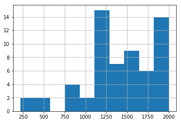

```python
apcs.euro.hist()
```

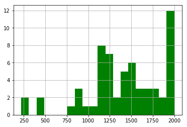

```python
#Um den Plot zu modifizieren:
apcs.euro.hist(bins=20, color="green")#Änderung der Balkenanzahl, Farbe
```

Matplotlib ist ein Tool, mit dem man viel machen kann in dieser Richtung. Hier nützt es uns, um mit wenigen Befehlen einen schnellen Plot, bzw. ein schnelles Histogramm zu erstellen.

Wollen wir uns das in eine Datei schreiben, ist das auch möglich. Jupytermagic: Gib uns die Graphiken direkt hier an.

Alle Libraries haben eine Dokumentation, so auch Pandas (auch Pandas Cookbook), wo alle möglichen Funktionen, Methoden, Attribute usw. gezeigt werden

## Python DOI JSON

Beziehen hierfür Daten aus Crossref (auch in unserem HackPad) https://api.crossref.org/works/

APIs: Programmierschnittstellen. Über das Ansprechen einer URL können wir bestimmte Dinge zurückbekommen (REST API)

```python
import urllib.request
import json #auch das eine Bibliothek
base_url ="https://api.crossref.org/works/" #variable mit der URL definieren JSON-Datei
doi = "10.1371/journal.pcbi.1004668"
```

```python
doi_json_data = urllib.request.urlopen(base_url + doi)#Mit + kann ich strings zusammenfügen (Konkatenation)
```

```python
type(doi_json_data)
```

```
http.client.HTTPResponse
```

Der Typ ist heir also erstmal was Nichtssagendes. Wir haben hier ein Objekt, das den Object-Response abbildet, das bringt uns aber zunächst nicht so viel. Wir müssen noch den Inhalt zurückgeben, damit wir damit was machen können

```python
doi_json_data_content = doi_json_data.read()
```

```python
print(doi_json_data_content)
```

```
b'{"status":"ok","message-type":"work","message-version":"1.0.0","message":{"indexed":{"date-parts":[[2019,2,15]],"date-time":"2019-02-15T18:42:53Z","timestamp":1550256173700},"reference-count":6,"publisher":"Public Library of Science (PLoS)","issue":"1","license":[{"URL":"http:\\/\\/creativecommons…
```

Sammlung von Dictionaries, sehr verschachtelt. Wir beutzen jetzt die JSON Library und schreiben die Daten in ein Python Dictionary um. loads steht im folgenden für "Load String"

```python
doi_data = json.loads(doi_json_data_content)
```

```python
type(doi_data)
```

```
dict
```

```python
doi_data.keys() #Keys anzeigen
```

```
dict_keys(['status', 'message-type', 'message-version', 'message'])
```

```python
print(json.dumps(doi_data, indent=2))#ausgeben mit Einzug 2, Dumps: Formatierer json-Daten in netter Ansicht
```

```
{
  "status": "ok",
  "message-type": "work",
  "message-version": "1.0.0",
  "message": {
    "indexed": {
      "date-parts": [
        [
          2019,
          2,
          15
        ]
      ],
      "date-time": "2019-02-15T18:42:53Z",
      "timestamp": 1550256173700
    },
    "reference-count": 6,
    "publisher": "Public Library of Science (PLoS)",
    "issue": "1",
    "license": [
      {
        "URL": "http://creativecommons.org/licenses/by/4.0/",
        "start": {
          "date-parts": [
            [
              2016,
              1,
              19
            ]
          ],
          "date-time": "2016-01-19T00:00:00Z",
          "timestamp": 1453161600000
        },
        "delay-in-days": 0,
        "content-version": "vor"
      }
    ],
    "content-domain": {
      "domain": [
        "www.ploscompbiol.org"
```

[output cut: 183 more lines]

```
    "URL": "http://dx.doi.org/10.1371/journal.pcbi.1004668",
    "relation": {
      "cites": []
    },
    "ISSN": [
      "1553-7358"
    ],
    "issn-type": [
      {
        "value": "1553-7358",
        "type": "electronic"
      }
    ]
  }
}
```

```python
type(doi_data["message"])
```

```
dict
```

```python
doi_data["message"].keys()
```

```
dict_keys(['indexed', 'reference-count', 'publisher', 'issue', 'license', 'content-domain', 'short-container-title', 'DOI', 'type', 'created', 'page', 'update-policy', 'source', 'is-referenced-by-count', 'title', 'prefix', 'volume', 'author', 'member', 'published-online', 'reference', 'container-tit…
```

```python
doi_data["message"]["title"]#Dies gibt eine Liste zurück -> mit Type wird das bestätigt
```

```
['A Quick Introduction to Version Control with Git and GitHub']
```

```python
doi_data["message"]["published-online"]
```

```
{'date-parts': [[2016, 1, 19]]}
```

```python
doi_data["message"]["URL"]
```

```
'http://dx.doi.org/10.1371/journal.pcbi.1004668'
```

```python
doi_data["message"]["container-title"]
```

```
['PLOS Computational Biology']
```

```python
doi_data["message"]["DOI"]
```

```
'10.1371/journal.pcbi.1004668'
```

```python
doi_data["message"]["reference"]#Liste der References ist eine Liste von Dictionaries, jedes Dictionary eine Zitation
```

```
[{'key': 'ref1',
  'doi-asserted-by': 'crossref',
  'first-page': '7',
  'DOI': '10.1186/1751-0473-8-7',
  'article-title': 'Git can facilitate greater reproducibility and increased transparency in science',
  'volume': '8',
  'author': 'K Ram',
  'year': '2013',
  'journal-title': 'Source Code Biol Med'},
 {'key': 'ref2',
  'doi-asserted-by': 'crossref',
  'first-page': 'e1001745',
  'DOI': '10.1371/journal.pbio.1001745',
  'article-title': 'Best practices for scientific computing',
  'volume': '12',
  'author': 'G Wilson',
  'year': '2014',
  'journal-title': 'PLoS Biol'},
 {'key': 'ref3',
  'doi-asserted-by': 'crossref',
  'first-page': '57',
  'DOI': '10.1038/nature11247',
  'article-title': 'An integrated encyclopedia of DNA elements in the human genome',
  'volume': '489',
  'author': 'B Bernstein',
  'year': '2012',
  'journal-title': 'Nature'},
 {'key': 'ref4',
  'doi-asserted-by': 'crossref',
  'first-page': 'e1003326',
  'DOI': '10.1371/journal.pcbi.1003326',
  'article-title': 'Practical guidelines for the comprehensive analysis of ChIP-seq data',
  'volume': '9',
  'author': 'T Bailey',
  'year': '2013',
  'journal-title': 'PLoS Comput Biol'},
 {'key': 'ref5',
  'doi-asserted-by': 'crossref',
  'first-page': 'e1000424',
  'DOI': '10.1371/journal.pcbi.1000424',
  'article-title': 'A quick guide to organizing computational biology projects',
  'volume': '5',
  'author': 'W Noble',
  'year': '2009',
  'journal-title': 'PLoS Comput Biol'},
 {'key': 'ref6',
  'doi-asserted-by': 'crossref',
  'first-page': 'e1002598',
  'DOI': '10.1371/journal.pcbi.1002598',
  'article-title': 'A quick guide to software licensing for the scientist-programmer',
  'volume': '8',
  'author': 'A Morin',
  'year': '2012',
  'journal-title': 'PLoS Comput Biol'}]
```

```python
doi_data["message"]["reference"][0].keys()#Keys zum ersten Reference-Dictionary
```

```
dict_keys(['key', 'doi-asserted-by', 'first-page', 'DOI', 'article-title', 'volume', 'author', 'year', 'journal-title'])
```

```python
doi_data["message"]["reference"][0]["DOI"]#DOI der ersten Zitation
```

```
'10.1186/1751-0473-8-7'
```

```python
#Obiges nochmal zusammenfassend
doi_json_data = urllib.request.urlopen(base_url + doi).read()
#print(doi_json_data)
doi_data=json.loads(doi_json_data) #loads=load string
#Haben unser Dictionary
#doi_data["message"]["title"]#gibt Liste
#doi_data["message"]["title"][0] #1. Element in der Liste
print("- ", doi_data["message"]["title"][0])#sieht schöner aus
print( ". - In:", doi_data["message"]["container-title"][0])
print()
```

```
-  A Quick Introduction to Version Control with Git and GitHub
. - In: PLOS Computational Biology
```

```python
dois = ["10.1371/journal.pcbi.1004668",
        "10.21105/joss.01035",
        "10.1038/35057062",
        "10.21105/joss.01006"]
for doi in dois:
    doi_json_data = urllib.request.urlopen(base_url + doi).read()
    doi_data=json.loads(doi_json_data)
    print("DOI: ", doi_data["message"]["DOI"])
    print("Title: ", doi_data["message"]["title"][0])#sieht schöner aus
    print( "Journal title: ", doi_data["message"]["container-title"][0])
    print()
```

```
DOI:  10.1371/journal.pcbi.1004668
Title:  A Quick Introduction to Version Control with Git and GitHub
Journal title:  PLOS Computational Biology

DOI:  10.21105/joss.01035
Title:  nasapower: A NASA POWER Global Meteorology, Surface Solar Energy and Climatology Data Client for R
Journal title:  Journal of Open Source Software

DOI:  10.1038/35057062
Title:  Initial sequencing and analysis of the human genome
Journal title:  Nature

DOI:  10.21105/joss.01006
Title:  SeqTools: A python package for easy transformation, combination and evaluation of large datasets.
Journal title:  Journal of Open Source Software
```

Auch Aleph hat ein API, theoretisch könnte man auch dort mit den hier vorgestellten Tools arbeiten.

# GIT

### Einführung

Der Linuxkernel-Entwickler hat festgestellt, dass bestimmte Sachen mit deren System nicht funktionierten, hat daher GIT entwickelt.

Es ist gewissermaßen ein "Source-Code Versionierungssystem". Ältere ähnliche Systeme sind SVN und CVS. Unterschied zu GIT: diese waren zentral organisiert.

Git ist dagegen dezentral. Es ermöglicht die Speicherung von Softwareversion.

Anstatt dass man also verschiedene Dateien mit Versionen anlegt. Problematisch wird es spätestens dann, wenn man mehrere, interagierende Dateien hat, deren Versionsgeschichte man verfolgen möchte.

Zudem möchte man nachsehen können, vergleichen können, WAS genau im Verlauf geändert wurde (von Version zu Version etwa).

Da solche Dinge in der Regel nicht alleine entwickelt werden, gibt es die Möglichkeit, sie auf Plattformen verfügbar und kollaborativ bearbeitbar zu machen (und dabei immer Versionen zu tracken!)

Bspw Plattformen: GitHub, GitLab.

Alle Carpentrysachen können (und werden) auf diese Weise global kollaborativ Dinge entwickelt, dokumentiert, geteilt.

Git ist tatsächlich dafür ausgerichtet, kleinere Dateien anzusehen. Es gibt jedoch für größere Sachen Erweiterungen. Es gibt Ansätze, Wege zu finden, dies auch für Forschungsdaten zu nutzen und Daten zur Verfügung zu stellen.

GitLab ist wie GitHub (aufgekauft von Microsoft) eine Firma, aber auch eine Software, sodass man so eine Plattform auch intern aufbauen kann. GitLab.com ist zudem ebenfalls eine Plattform.

Bei GitLab gibt es zudem die Möglichkeit, ein Repositorium oder Projekt zu erstellen, dass öffentlich sichtbar ist oder nur von registrierten Nutzern oder tatsächlich nur auf explizite Einladung. GitLab bietet da verschiedene Späße.

NUN: GIT allein können wir nutzen, um Dinge zu tracken und werden dann das Ganze mal über GitHub weiter verstehen.

Werden nun ein Repositorium (GIT) erstellen, welches wir später spiegeln und auf GitHub hochladen können (gewissermaßen einen Klon des Projekts). Wir können Änderungen nun in GitHub vornehmen oder lokal und jeweils synchronisieren. Ebenso wird es möglich sein, das Repositorium einer anderen Person forwarden und im eigenen Bereich haben und bearbeiten. Mit einem Pullrequest kann man dann entsprechend anbieten, dass die Originalkopie wiederum entsprechend geändert wird.

Das System mit dem Forward und Pullrequest hat das Patch-System (Änderungsvorschläge) abgelöst und funktioniert viel reibungsloser.

### Konkret

Arbeiten wieder in unserer UNIX shell

In unserem Kontext heißt eine Sammlung von Code für ein Projekt REPOSITORIUM

Wir müssen GIT erstmal sagen, wer wir sind.

```
git config --global user.name "dinaglhess"
git init
git status
git add
```

Dabei entsteht ein .git Ordner, den wir nicht anfassen :) - Die Git-Zauberei findet darin statt! Da ist alles drin, was wir machen! Nicht löschen! :)

Zunächst weiß Git noch nichts: "untracked files" haben noch nichts committed (d.h. bislang noch nicht gesagt, was beobachtet werden soll).

```
git add dateiname
```

Dateien ins Staging Area. Warnung sagt nur, dass Wörter (LF Linefeed durch CRLF Carriage Return Line Feed) ersetzt wird

```
git commit -m "Committen mit commit message"
```

```
git status
git diff
```

Was hat sich geändert?